# Lab 2: Exploring Rodents with `ggplot2`

Author

Trycia Vong

# Setup

```r
# code for loading packages goes here!
library(tidyverse)
```

# Data Context

The Portal Project is a long-term ecological study being conducted near Portal, AZ. Since 1977, the site has been used to study the interactions among rodents, ants, and plants, as well as their respective responses to climate. To study the interactions among organisms, researchers experimentally manipulated access to 24 study plots. This study has produced over 100 scientific papers and is one of the longest running ecological studies in the U.S.

We will be investigating the animal species diversity and weights found within plots at the Portal study site for a subset of the study data. The data are stored as a comma separated value (CSV) file. Each row holds information for a single animal, and the columns represent:

| Column | Description |
| --- | --- |
| `record_id` | Unique ID for the observation |
| `month` | month of observation |
| `day` | day of observation |
| `year` | year of observation |
| `plot_id` | ID of a particular plot |
| `species_id` | 2-letter code |
| `sex` | sex of animal (“M”, “F”) |
| `hindfoot_length` | length of the hindfoot in mm |
| `weight` | weight of the animal in grams |
| `genus` | genus of animal |
| `species` | species of animal |
| `taxa` | e.g. Rodent, Reptile, Bird, Rabbit |
| `plot_type` | type of plot |

# Reading the Data into `R`

```r
# Code for question 0!
surveys <- read_csv(file = "surveys.csv")
surveys
```

```
# A tibble: 30,463 × 15
   record_id month   day  year plot_id species_id sex   hindfoot_length weight
       <dbl> <dbl> <dbl> <dbl>   <dbl> <chr>      <chr>           <dbl>  <dbl>
 1        63     8    19  1977       3 DM         M                  35     40
 2        64     8    19  1977       7 DM         M                  37     48
 3        65     8    19  1977       4 DM         F                  34     29
 4        66     8    19  1977       4 DM         F                  35     46
 5        67     8    19  1977       7 DM         M                  35     36
 6        68     8    19  1977       8 DO         F                  32     52
 7        69     8    19  1977       2 PF         M                  15      8
 8        71     8    19  1977       7 DM         F                  36     35
 9        74     8    19  1977       8 PF         M                  12      7
10        75     8    19  1977       8 DM         F                  32     22
# ℹ 30,453 more rows
# ℹ 6 more variables: date <date>, day_of_week <chr>, plot_type <chr>,
#   genus <chr>, species <chr>, taxa <chr>
```

**1. What are the dimensions (# of rows and columns) of these data?**

```r
# https://how.dev/answers/how-to-check-the-dimension-of-a-dataframe-in-r
dim(surveys)
```

```
[1] 30463    15
```

**2. What are the data types of the variables in this dataset?**

```r
spec(surveys)
```

[output not shown]

**3. What kinds of animals are included in the dataset? Birds? Rabbits? ect. (Hint: you will want to look at the variable descriptions to answer this question)**

```r
# Code for question 3!
uniqueTaxa <- unique(surveys$taxa)
uniqueTaxa
```

```
[1] "Rodent"
```

# Exploratory Data Analysis with **`ggplot2`**

`ggplot()` graphics are built step by step by adding new elements. Adding layers in this fashion allows for extensive flexibility and customization of plots.

To build a `ggplot()`, we will use the following basic template that can be used for different types of plots:

```r
ggplot(data = <DATA>,
       mapping = aes(<VARIABLE MAPPINGS>)) +
  <GEOM_FUNCTION>()
```

Let’s get started!

## Scatterplot

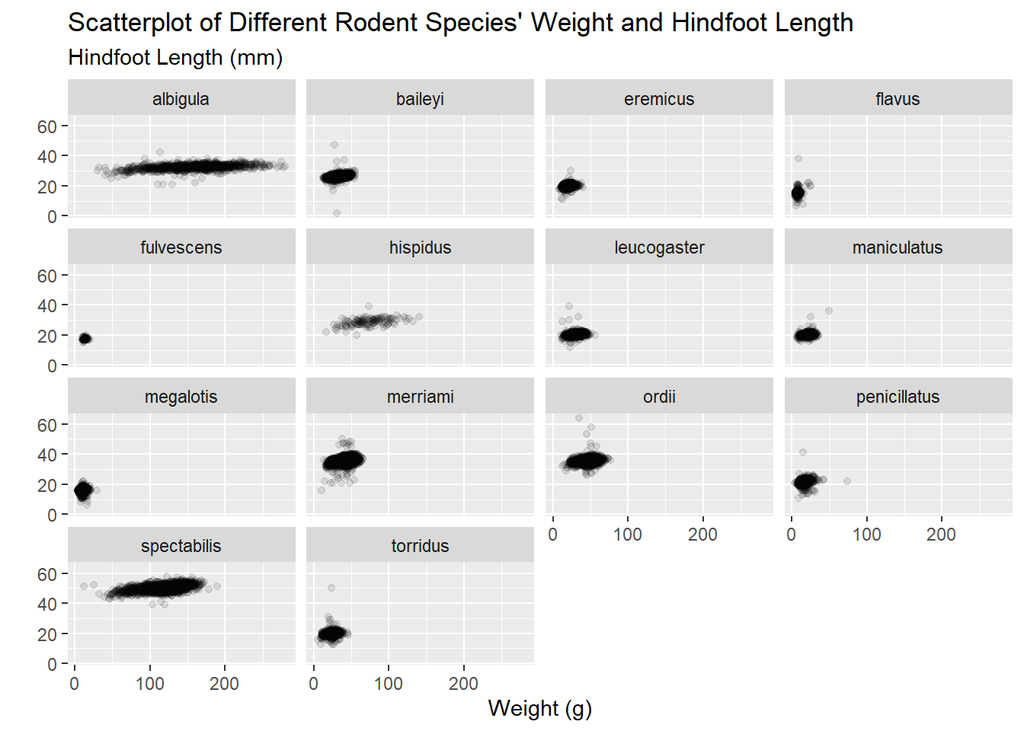

```r
# Scatterplot code for question s 4-8!
ggplot(data = surveys, mapping = aes(x = weight, y = hindfoot_length)) +
  geom_point(alpha = 0.1) +
  facet_wrap(vars(species)) +
  labs(title = "Scatterplot of Different Rodent Species' Weight and Hindfoot Length", subtitle = "Hindfoot Length (mm)", x = "Weight (g)", y = "")
```

## Boxplots

**Excalidraw**

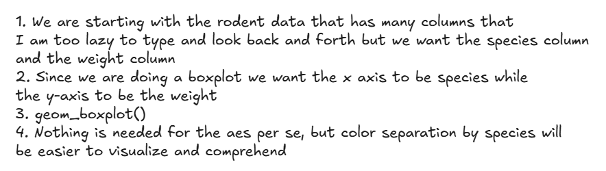

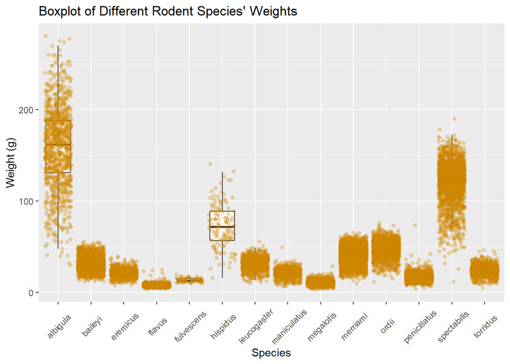

```r
#https://stackoverflow.com/questions/1330989/rotating-and-spacing-axis-labels-in-ggplot2
# Boxplot code for question 10 - 15!
ggplot(data = surveys, mapping = aes(x = species, y = weight)) +
  labs(title = "Boxplot of Different Rodent Species' Weights", x = "Species", y = "Weight (g)") +
  theme(axis.text.x = element_text(angle = 45, vjust = 0.5)) +
  geom_boxplot(outlier.shape = NA) +
  geom_jitter(alpha = 0.3, color = "orange3")
```

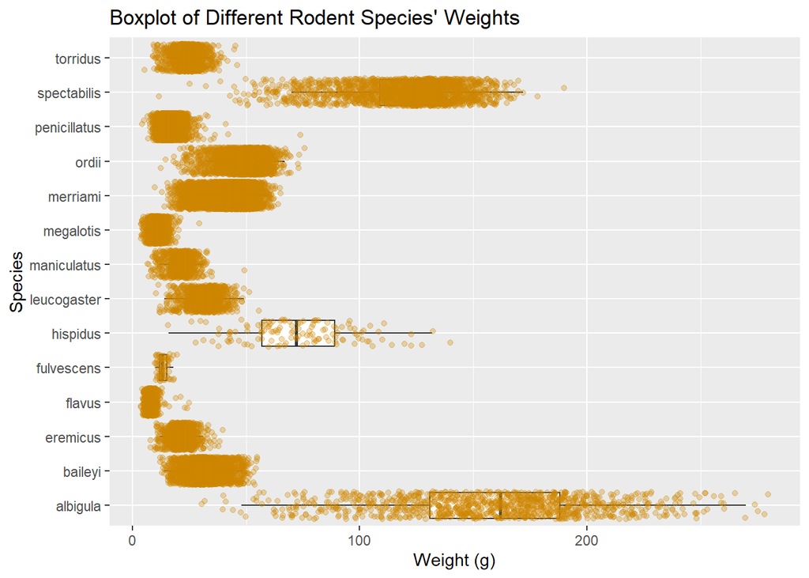

```r
#https://r-charts.com/distribution/box-plot-ggplot2/#:~:text=There%20are%20two%20main%20ways,Option%201%3A%20changing%20the%20argument.&text=Option%202%3A%20using%20coord_flip%20.
# Copy-paste boxplot code. Then modify for question 16!
ggplot(data = surveys, mapping = aes(x = species, y = weight)) +
  labs(title = "Boxplot of Different Rodent Species' Weights", x = "Species", y = "Weight (g)") +
  geom_boxplot(outlier.shape = NA) +
  coord_flip() +
  geom_jitter(alpha = 0.3, color = "orange3")
```

Notice how vertically stacked boxplots make the species labels more readable than horizontally stacked boxplots. This is good practice!

# Conducting Statistical Analyses

Exploratory Data Analysis (EDA) is always a great start to investigating a dataset. Can we see a relationship between rodent weight and hindfoot length? How does rodent weight differ between species? After performing EDA, we can then conduct appropriate statistical analyses to formally investigate what we have seen.

In this section, we are going to conduct a one-way analysis of variance (ANOVA) to compare mean weight between the fourteen species.

**Refresher on one-way ANOVA**

While a second course in statistics is a pre-requisite for this class, you may want a [refresher](https://openintro-ims.netlify.app/inference-many-means) on conducting a one-way ANOVA.

I have outlined the null and alternative hypotheses we will be testing:

**Null**

The population mean weight is **the same** between **all** fourteen rodent species.

**Alternative**

**At least one** rodent species has a different population mean weight.

**17. Using `aov()`, complete the code below to carry out the analysis.**

```r
# response(number) ~ predictor(categorical), predict weight based on species
species_mod <- aov(surveys$weight ~ surveys$species, data = surveys)
summary(species_mod)
```

```
                   Df   Sum Sq Mean Sq F value Pr(>F)
surveys$species    13 34786303 2675869   19916 <2e-16 ***
Residuals       30449  4091063     134
---
Signif. codes:  0 '***' 0.001 '**' 0.01 '*' 0.05 '.' 0.1 ' ' 1
```

**18. Based on the results of the ANOVA F-test, draw a conclusion in context of the hypotheses. Make sure to cite appropriate output from above.**

**Conclusion:** Assuming alpha = 0.05, we reject the null hypothesis of the population mean weight being the same between all fourteen rodent species and conclude that there is at least one difference in one rodent species with a different population mean weight.

```r
library(emmeans)
```

**19. Using the `species_mod` from above and the `emmeans()` function, complete the code below to obtain estimated model mean rodent weights for each species**

```r
species_estimates <- emmeans(species_mod, specs = "species")
species_estimates
```

```
 species       emmean    SE    df lower.CL upper.CL
 albigula     158.785 0.359 30449  158.082  159.488
 baileyi       31.740 0.219 30449   31.311   32.169
 eremicus      21.577 0.335 30449   20.920   22.233
 flavus         7.956 0.302 30449    7.363    8.549
 fulvescens    13.479 1.360 30449   10.820   16.139
 hispidus      73.031 1.020 30449   71.023   75.039
 leucogaster   31.328 0.385 30449   30.573   32.083
 maniculatus   21.341 0.401 30449   20.555   22.128
 megalotis     10.583 0.236 30449   10.121   11.045
 merriami      43.136 0.118 30449   42.906   43.366
 ordii         48.867 0.219 30449   48.437   49.298
 penicillatus  17.188 0.213 30449   16.771   17.605
 spectabilis  120.226 0.258 30449  119.721  120.732
 torridus      24.217 0.254 30449   23.719   24.715

Confidence level used: 0.95
```

**20. Now that you have obtained the estimated model mean rodent weights, conduct pairwise comparisons using the `pairs()` function from the `emmeans` package.**

```r
# carry out pairwise comparisons between species.
pairwiseComparison <- pairs(species_estimates)
pairwiseComparison
```

```
 contrast                   estimate    SE    df  t.ratio p.value
 albigula - baileyi          127.045 0.420 30449  302.397  <.0001
 albigula - eremicus         137.208 0.491 30449  279.653  <.0001
 albigula - flavus           150.829 0.469 30449  321.543  <.0001
 albigula - fulvescens       145.305 1.400 30449  103.550  <.0001
 albigula - hispidus          85.753 1.090 30449   79.001  <.0001
 albigula - leucogaster      127.457 0.526 30449  242.156  <.0001
 albigula - maniculatus      137.443 0.538 30449  255.455  <.0001
 albigula - megalotis        148.201 0.429 30449  345.345  <.0001
 albigula - merriami         115.649 0.377 30449  306.485  <.0001
 albigula - ordii            109.917 0.420 30449  261.464  <.0001
 albigula - penicillatus     141.597 0.417 30449  339.622  <.0001
 albigula - spectabilis       38.558 0.442 30449   87.320  <.0001
 albigula - torridus         134.567 0.439 30449  306.202  <.0001
 baileyi - eremicus           10.163 0.400 30449   25.401  <.0001
 baileyi - flavus             23.784 0.373 30449   63.703  <.0001
 baileyi - fulvescens         18.260 1.370 30449   13.288  <.0001
 baileyi - hispidus          -41.291 1.050 30449  -39.413  <.0001
 baileyi - leucogaster         0.412 0.443 30449    0.929  0.9997
 baileyi - maniculatus        10.399 0.457 30449   22.754  <.0001
 baileyi - megalotis          21.157 0.322 30449   65.755  <.0001
 baileyi - merriami          -11.396 0.248 30449  -45.862  <.0001
 baileyi - ordii             -17.127 0.310 30449  -55.253  <.0001
 baileyi - penicillatus       14.552 0.305 30449   47.670  <.0001
 baileyi - spectabilis       -88.486 0.338 30449 -261.674  <.0001
 baileyi - torridus            7.523 0.335 30449   22.429  <.0001
 eremicus - flavus            13.621 0.451 30449   30.186  <.0001
 eremicus - fulvescens         8.097 1.400 30449    5.795  <.0001
 eremicus - hispidus         -51.454 1.080 30449  -47.737  <.0001
 eremicus - leucogaster       -9.751 0.511 30449  -19.102  <.0001
 eremicus - maniculatus        0.235 0.523 30449    0.451  1.0000
 eremicus - megalotis         10.993 0.410 30449   26.842  <.0001
 eremicus - merriami         -21.559 0.355 30449  -60.745  <.0001
 eremicus - ordii            -27.291 0.400 30449  -68.161  <.0001
 eremicus - penicillatus       4.389 0.397 30449   11.062  <.0001
 eremicus - spectabilis      -98.650 0.423 30449 -233.451  <.0001
 eremicus - torridus          -2.640 0.420 30449   -6.281  <.0001
 flavus - fulvescens          -5.524 1.390 30449   -3.974  0.0055
 flavus - hispidus           -65.076 1.070 30449  -60.919  <.0001
 flavus - leucogaster        -23.372 0.490 30449  -47.716  <.0001
```

[output cut: 39 more lines]

```
 megalotis - penicillatus     -6.605 0.318 30449  -20.798  <.0001
 megalotis - spectabilis    -109.643 0.349 30449 -313.902  <.0001
 megalotis - torridus        -13.634 0.347 30449  -39.333  <.0001
 merriami - ordii             -5.731 0.249 30449  -23.023  <.0001
 merriami - penicillatus      25.948 0.243 30449  106.766  <.0001
 merriami - spectabilis      -77.090 0.283 30449 -272.168  <.0001
 merriami - torridus          18.919 0.280 30449   67.577  <.0001
 ordii - penicillatus         31.679 0.306 30449  103.652  <.0001
 ordii - spectabilis         -71.359 0.338 30449 -210.819  <.0001
 ordii - torridus             24.650 0.336 30449   73.420  <.0001
 penicillatus - spectabilis -103.038 0.334 30449 -308.343  <.0001
 penicillatus - torridus      -7.029 0.331 30449  -21.212  <.0001
 spectabilis - torridus       96.009 0.362 30449  265.284  <.0001

P value adjustment: tukey method for comparing a family of 14 estimates
```

# Use Your Graphics Skills for Evil

**21. Create the *ugliest version* of a scatterplot showing the relationship between `weight` and `hindfoot_length` (where you started in Q4). Then, *explain why* you made the decisions you did, and which principles of good graphics you’ve intentionally violated.**

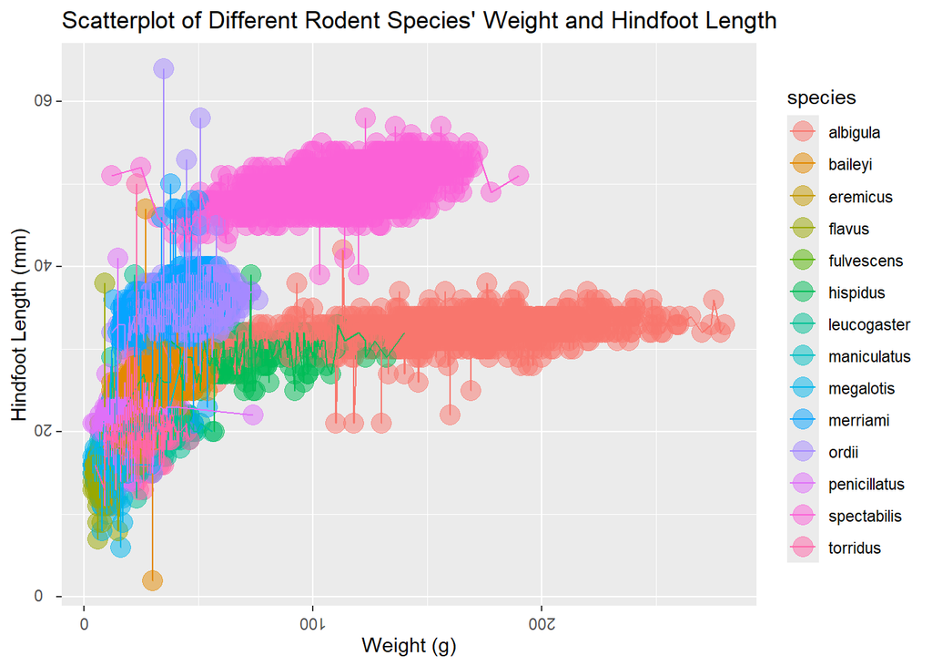

```r
# Make your ugly graphic here!
ggplot(data = surveys, mapping = aes(x = weight, y = hindfoot_length)) +
  geom_point(alpha = 0.5, aes(color = species), size = 5) +
  geom_line(aes(color = species)) +
  labs(title = "Scatterplot of Different Rodent Species' Weight and Hindfoot Length", x = "Weight (g)", y = "Hindfoot Length (mm)") +
  theme(axis.text.x = element_text(angle = 180), axis.text.y = element_text(angle = 180))
```

```r
#Removed the facetting so you only have to look at one chart (now you cant see properly indiv pts properly),
#various colors to be more visually appealing (too many rainbow colors, hard for colorblind ppl), made the points bigger (visual clutter), #added lines to see each species (visual clutter), rotated the axis labels (too much brain power)
```